# Cyclistic Report Through Divvy Bikes 2024

Ferry

2026-02-25

## Business Context

#### Situation

Cyclistic is a bike-share company seeking to **maximizing the number of annual memberships**. The marketing team wants to understand **how casual riders and annual members use Cyclistic bikes differently** to support their conversion strategy.

#### Objective

Understand how annual members and casual riders use Cyclistic bike differently based on ride history.

#### Key Questions

1. What is the proportion of rides made by annual members and casual riders in the past year?
2. What patterns differentiate between annual members and casual riders?

## Ride Distribution

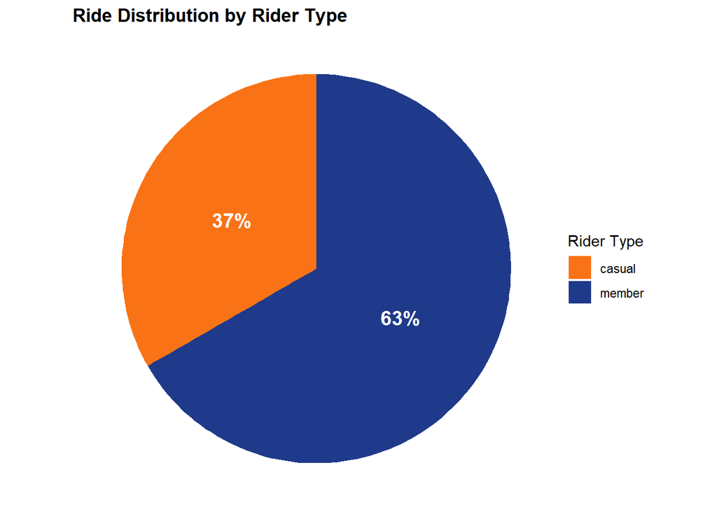

Over the past year, 37% of rides were made by casual riders, with 63% of rides by annual members. This indicates that **annual members are dominant in ride usage**. However, casual riders still make up for more than a third by usage, which opens for conversion opportunities.

## Median Ride Duration

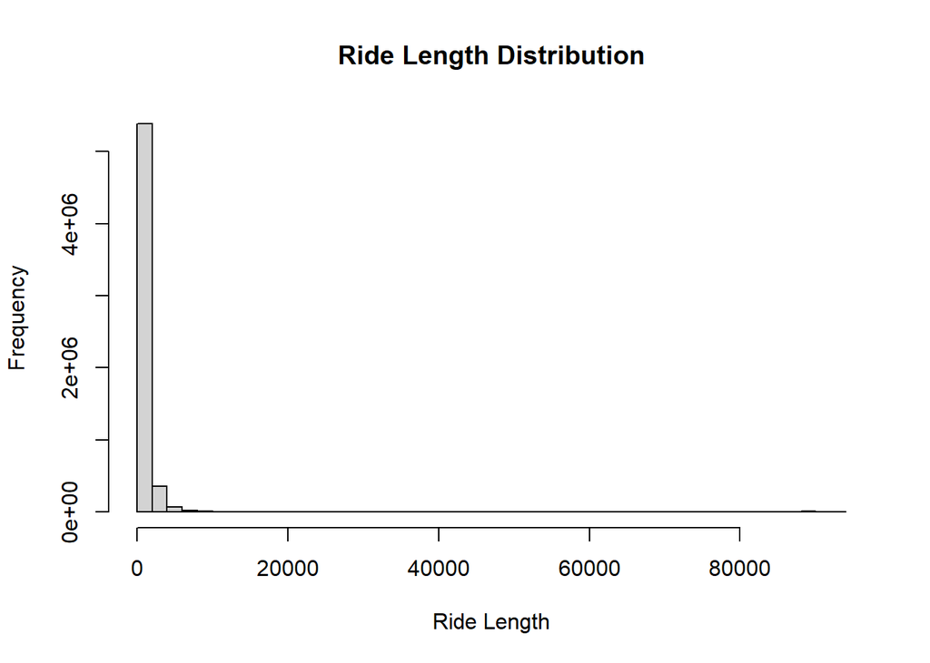

Ride length data is right-skewed due to the presence of extreme long rides, resulting in a noticeable difference between mean and median values. Therefore, median is used to represent typical ride behavior and provide a fair comparison between casual riders and annual members.

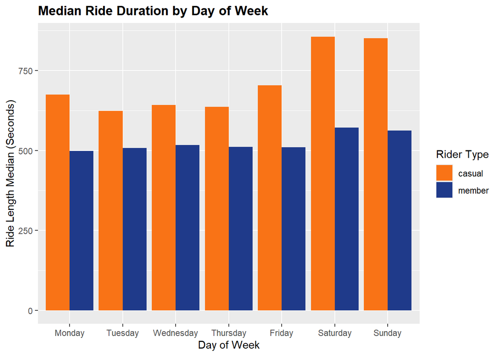

**casual riders tend to take longer ride duration** on median, indicating a more relaxed usage, whereas **annual members are more efficient**.

## Weekly Ride Frequency

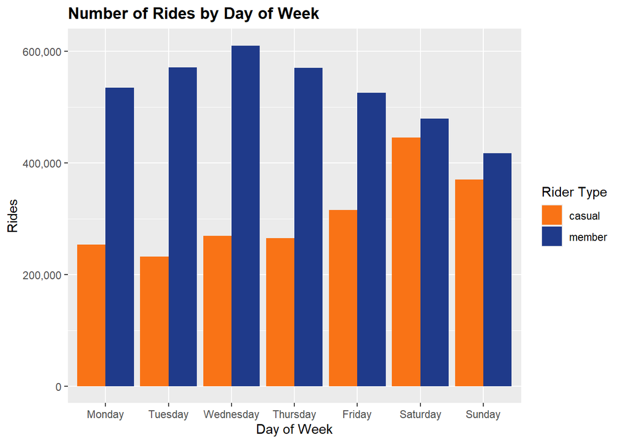

**Annual members demonstrate a consistent weekday** riding pattern, peaking on Wednesday (Mid-week), which **strongly suggests routine commuting behavior**. In contrast, **casual riders show significantly higher rides on weekends**, peaking on Saturday, indicating **leisure-oriented usage**.